# Week 3 Peer Review

Following the directions on the Coursera assignment page, you will make four original visualizations.

### Put your name here: Marcio Woitek

## Exercise 1

**Explain what you are visualizing here:**

For this exercise, I’ll use the CEL data. Specifically, I’ll utilize some data related to the 114th Congress. For this Congress, I want to answer the following question: how are the members distributed according to gender? Then I’m going to create a bar plot that shows the number of men and the number of women in the 114th Congress. The numbers corresponding to Democrats and Republicans will be presented separately.

**Put your figure here:**

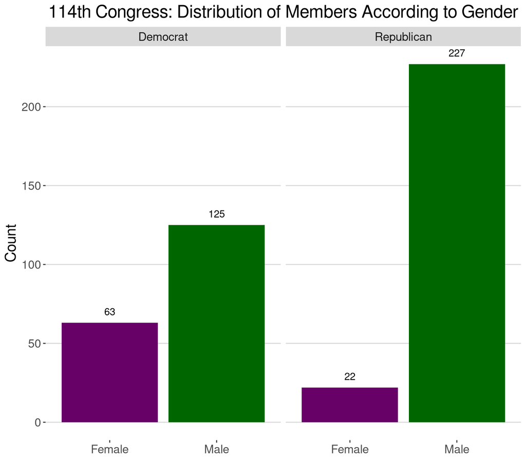

## Exercise 2

**Explain what you are visualizing here:**

Once again, I’m using the CEL data. This time I’ll visualize the change in the ideology of the members of Congress (as measured by the DW-Nominate score) over a time period of 20 years. To do so, I’m going to consider only the data associated with the last 10 Congresses included in the dataset. For each party, I’ll create a set of box plots. The $i$-th box will show the distribution of the `dwnom1` variable corresponding to the $i$-th Congress.

**Put your figure here:**

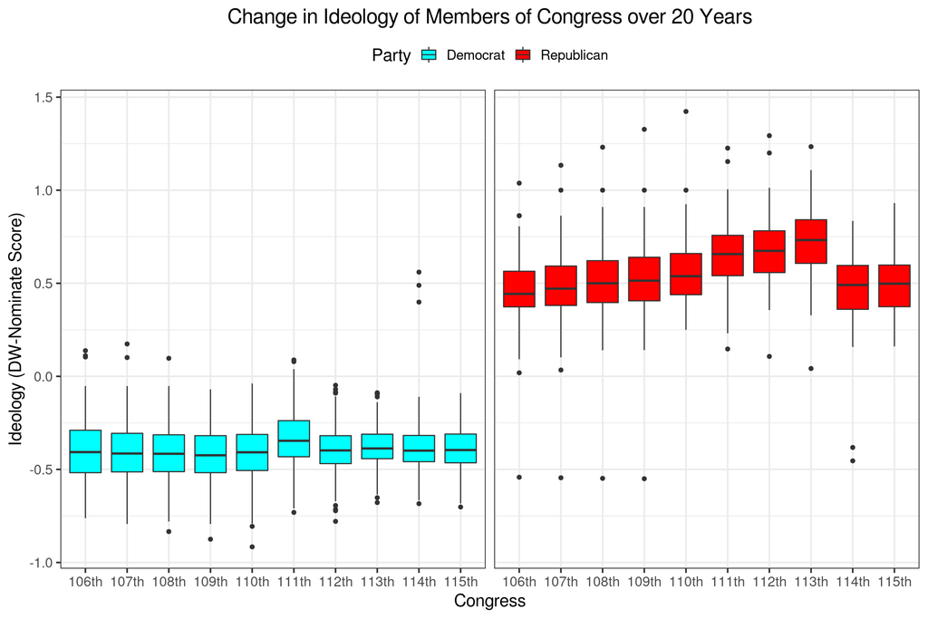

## Exercise 3

**Explain what you are visualizing here:**

For this exercise, I’m going to use a dataset called `nottem`. This is one of R’s built-in datasets. It contains average air temperatures at Nottingham for 20 years (1920-1939). These are monthly averages, given in degrees Fahrenheit.

Arbitrarily, I chose to consider the year 1927. For this year, I’ll create a line plot showing the changes in temperature over the months.

This is the data I’m going to plot:

| Month | Temperature |
| --- | --- |
| Jan | 39.4 |
| Feb | 38.5 |
| Mar | 45.3 |
| Apr | 47.1 |
| May | 51.7 |
| Jun | 55.0 |
| Jul | 60.4 |
| Aug | 60.5 |
| Sep | 54.7 |
| Oct | 50.3 |
| Nov | 42.3 |
| Dec | 35.2 |

**Put your figure here:**

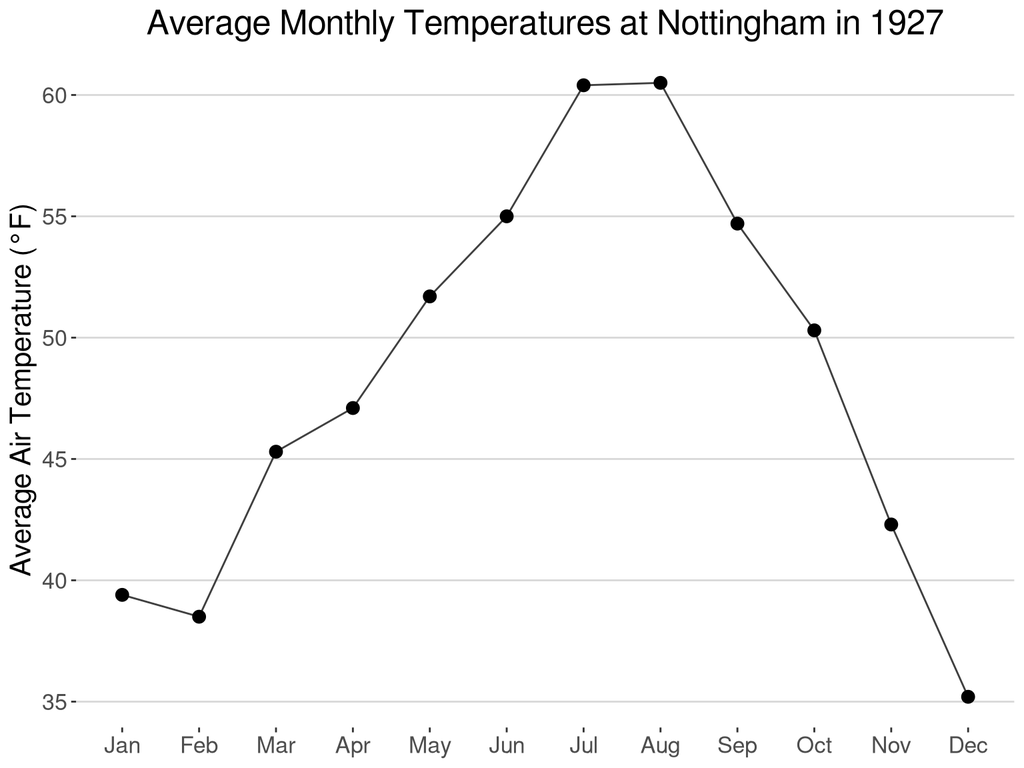

## Exercise 4

**Explain what you are visualizing here:**

For this last exercise, I’ll use “fake” data. More precisely, I’m going to generate some data related to a variable $y$ that can be modeled as a linear function of another variable $x$. Arbitrarily, I chose the theoretical relation between $x$ and $y$ to be the following: $y = 5 - \frac{x}{2}$. To make things a little more interesting, I’ll also add some noise to $y$. Using my synthetic data, I’ll create a scatter plot.

This is the data I’m going to plot:

| x | y (Theoretical) | y (with Noise) |
| --- | --- | --- |
| -3.0000000 | 6.500000 | 6.738018 |
| -2.5789474 | 6.289474 | 6.148779 |
| -2.1578947 | 6.078947 | 6.002222 |
| -1.7368421 | 5.868421 | 5.912133 |
| -1.3157895 | 5.657895 | 5.902819 |
| -0.8947368 | 5.447368 | 5.268378 |
| -0.4736842 | 5.236842 | 5.475876 |
| -0.0526316 | 5.026316 | 5.293121 |
| 0.3684211 | 4.815790 | 4.912268 |
| 0.7894737 | 4.605263 | 4.682732 |
| 1.2105263 | 4.394737 | 4.131809 |
| 1.6315789 | 4.184210 | 4.007795 |
| 2.0526316 | 3.973684 | 3.779618 |
| 2.4736842 | 3.763158 | 3.875372 |
| 2.8947368 | 3.552632 | 3.483094 |
| 3.3157895 | 3.342105 | 3.504010 |
| 3.7368421 | 3.131579 | 3.130199 |
| 4.1578947 | 2.921053 | 3.051624 |
| 4.5789474 | 2.710526 | 3.005670 |
| 5.0000000 | 2.500000 | 2.428021 |

**Put your figure here:**

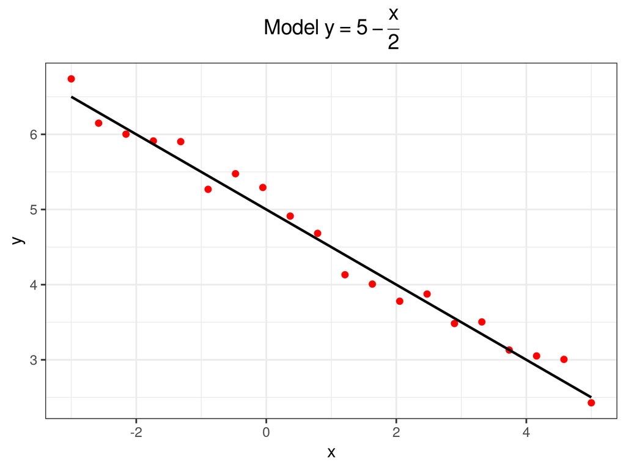